# Factors that influence price

For this analysis, we are going to analyze the factor that impact prices from business owners perspectives. This analysis can be used to determine the types of wine, winery to build, where to dedicate resources to build a winery, and given that the business owner wants to target a specific market segment.

```r
country.name <- "country"
description.name <- "description"
designation.name <- "designation"
points.name <- "points"
price.name <- "price"
province.name <- "province"
region_1.name <- "region_1"
region_2.name <- "region_2"
taster.name <- "taster_name"
twitter.name <- "taster_twitter_handle"
title.name <- "title"
variety.name <- "variety"
winery.name <- "winery"

dat[,eval(points.name)] <- as.numeric(dat[,get(points.name)])
dat[,eval(price.name)] <- as.numeric(dat[,get(price.name)])

single.var <- c(points.name, price.name, country.name)

dat$description <- NULL

price.category.range <- c(4,10,15,20,30,50,100,200)
price.category.name <- c('Value','Value Premium','Premium','Super Premium','Ultra Premium',
                         'Luxury','Super Luxury','Icon')

# Calculating unique values in the dataset
unique.designation <- length(unique(dat$designation))
unique.province <- length(unique(dat$province))
unique.variety <- length(unique(dat$variety))

designation.min <- 50
variety.min <- 200
province.min <- 500
```

```r
round.numerics <- function(x, digits){
  if(is.numeric(x)){
    x <- round(x = x, digits = digits)
  }
  return(x)
}

linear.regression.summary <- function(lm.mod, digits = 3, alpha = 0.05) {
lm.coefs <- as.data.table(summary(lm.mod)$coefficients,
keep.rownames = TRUE)
setnames(x = lm.coefs, old = "rn", new = "Variable")
z <- qnorm(p = 1 - alpha/2, mean = 0, sd = 1)
lm.coefs[, Coef.Lower.95 := Estimate - z * `Std. Error`]
lm.coefs[, Coef.Upper.95 := Estimate + z * `Std. Error`]
return(lm.coefs[])
}
```

### Test the correlation between the variables

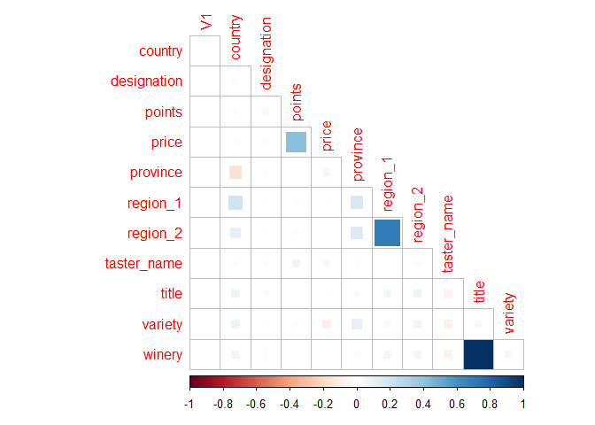

```r
library(corrplot)
data.numeric <- dat

data.numeric$country <- as.numeric(as.factor(data.numeric$country))
data.numeric$designation <- as.numeric(as.factor(data.numeric$designation))
data.numeric$province <- as.numeric(as.factor(data.numeric$province))
data.numeric$region_1 <- as.numeric(as.factor(data.numeric$region_1))
data.numeric$region_2 <- as.numeric(as.factor(data.numeric$region_2))
data.numeric$taster_name <- as.numeric(as.factor(data.numeric$taster_name))
data.numeric$title <- as.numeric(as.factor(data.numeric$title))
data.numeric$variety <- as.numeric(as.factor(data.numeric$variety))
data.numeric$winery <- as.numeric(as.factor(data.numeric$winery))

correlation.value <- cor(data.numeric)
corrplot(correlation.value, method = 'square',type = 'lower',diag = F)
```

We built a linear regression model that analyzes the factors that impact price using country, designation, points, province, region_1, taster_name, variety, and winery. The analysis that the variables that impact price are designation, province, points, region_1, and variety. It’s also important to note that the reviewers rating isn’t significant. Given that price and points have a moderate correlation, it would indicate that the reviewers are unbiased in their review. However, interpreting the variables presents a number of challenges:

There are 7 categorical values in the dataset, and it becomes difficult to interpret the beta variables. The model is indicating that an increase in the designation decreases the estimate. There are a number of ways to address including convert the character variables into factors, however, designation has 35754 levels.

The linear regression model is predicting a continuously variable output, for this audience, a small difference in price isn’t meaningful to analyze, i.e. the difference between a wine priced at 10.50 vs 11.00. We want to be able to capture a larger differences in price.

```r
# drop correlated values
data.numeric2 <- data.numeric
data.numeric2$title <- NULL
data.numeric2$region_2 <- NULL

# Fit linear Model
lm.model <- lm(price ~., data = data.numeric2)
lm.model.summary <- linear.regression.summary(lm.model)[,c(1,2,5:7)]
lm.model.summary[,2:5] <- round(lm.model.summary[,2:5],3)
datatable(lm.model.summary)
```

|  | Variable | Estimate | Pr(>\|t\|) | Coef.Lower.95 | Coef.Upper.95 |
| --- | --- | --- | --- | --- | --- |
| 1 | (Intercept) | -451.334 | 0 | -457.517 | -445.151 |
| 2 | V1 | 0 | 0.422 | 0 | 0 |
| 3 | country | 0.008 | 0.3 | -0.008 | 0.025 |
| 4 | designation | 0 | 0 | 0 | 0 |
| 5 | points | 5.582 | 0 | 5.513 | 5.651 |
| 6 | province | -0.012 | 0 | -0.014 | -0.01 |
| 7 | region_1 | 0.001 | 0 | 0 | 0.001 |
| 8 | taster_name | 0.006 | 0.75 | -0.031 | 0.043 |
| 9 | variety | -0.013 | 0 | -0.014 | -0.011 |
| 10 | winery | 0 | 0.097 | 0 | 0 |

[output not shown]

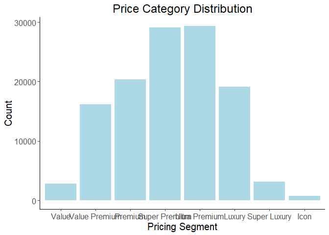

```r
dat$price <- cut2(x = dat$price,cuts = price.category.range, price.category.name)
levels(dat$price) <- price.category.name
price.count <- dat[,.(count = .N), by = price.name]

ggplot(data = price.count, aes(x = price, y = count)) +
  geom_bar(stat = 'identity', fill = 'lightblue') + theme_classic() +
  ggtitle('Price Category Distribution') + theme(legend.position = "bottom",
              text = element_text(size=15),
              axis.text.x = element_text(angle=0),
              plot.title = element_text(hjust = 0.5)) + xlab('Pricing Segment') + ylab('Count')
```

A deeper dive into the categorical variables reveals that a significant portion of the categorical variables have very few observations. Lack of sufficient variables greatly impacts the strength of analysis and conclusion. In the next section, we are going to filter variables with insufficient variables.

How many unique variables are in designation, province, and variety?

```r
paste0('There are ', length(unique(dat$designation)), ' unique observation values in the dataset')
```

```
[1] "There are 35754 unique observation values in the dataset"
```

```r
paste0('There are ', length(unique(dat$province)), ' unique province values in the dataset')
```

```
[1] "There are 422 unique province values in the dataset"
```

```r
paste0('There are ', length(unique(dat$variety)), ' unique variety values in the dataset')
```

```
[1] "There are 691 unique variety values in the dataset"
```

Given that we now have 8 dependent variables, a linear or logistic regression isn’t the best model to determine the factors that influence. After researching this problem, the best models that can address this situation are Multinomial regression and ordinal logit model.

**Ordinal Logistic Regression**

Ordinal logistic regression or (ordinal regression) is used to predict an ordinal dependent variable given one or more independent variables. Ordinal regression will enable us to determine which of our independent variables (if any) have a statistically significant effect on our dependent variable. For categorical independent variables, we can interpret the odds that one “group” have a higher or lower score on our dependent variable. For continuous independent variables, we are able to interpret how a single unit increase or decrease in that variable, is associated with the odds of our dependent variable having a higher or lower value We can also determine how well our ordinal regression model predicts the dependent variable.

Ordinal regression can only be performed under these 4 conditions:

- The dependent variable is measured on an ordinal level: Yes, the dependent variables range from value to Icon. Value is considered as a cheaper option and Icon is the most expensive
- One or more of the independent variables are either continuous, categorical or ordinal: The idenpendent variables are categorical and continuous
- No Multi-collinearity - i.e. when two or more independent variables are highly correlated with each other: Yes, We have removed all the variables that are highly correlated with each other.
- Proportional Odds - i.e. that each independent variable has an identical effect at each cumulative split of the ordinal dependent variable. Yes, the price is measured in the same currency and has the dependent on the quality of the wine

**Multinomial logistic regression**

The ratio of the probability of choosing one outcome category over the probability of choosing the baseline category is often referred as relative risk (and it is sometimes referred to as odds, described in the regression parameters above). The relative risk is the right-hand side linear equation exponentiated, leading to the fact that the exponentiated regression coefficients are relative risk ratios for a unit change in the predictor variable. We can exponentiate the coefficients from our model to see these risk ratios.

*Note:* we did not calculate the associated p value for the MLR. the formula to calculate it is: `z <- summary(model)$coefficients/summary(model)$standard.errors` followed by `p <- (1 - pnorm(abs(z), 0, 1)) * 2`.This calculation is computationally expensive, and we ran it several time without any success. We will assume that the variables have a significant p value.

#### Analyzing Province Impact

```r
dat.notable.provice.count <- dat[, .N, by = province.name][N > province.min]
dat.notable.provice <- dat[get(province.name) %in% dat.notable.provice.count$province]
multinom.model.province <- nnet::multinom(formula = price ~ province, data = dat.notable.provice)
```

The model summary output has a the odds ratio of each province and their respective price segment. It can be interpreted as the odd ratio of finding wine in price segment in a province compared to the baseline. For example: Alasce provice has a 7x higher odds ratio of finding a wine in the value premium and Alasce vs the base Price Segmnent and province.

```r
multinom.model.province.coef <- round(data.frame(exp(coef(multinom.model.province)),2))
datatable(multinom.model.province.coef)
```

|  | X.Intercept. | provinceAlsace | provinceBeaujolais | provinceBordeaux | provinceBurgenland | provinceBurgundy | provinceCalifornia | provinceCasablanca.Valley | provinceCatalonia | provinceCentral.Italy | provinceChampagne | provinceColchagua.Valley | provinceDouro | provinceFrance.Other | provinceLanguedoc.Roussillon | provinceLoire.Valley | provinceMaipo.Valley | provinceMarlborough | provinceMendoza.Province | provinceMosel | provinceNew.York | provinceNortheastern.Italy | provinceNorthern.Spain | provinceOregon | provinceOther | provincePiedmont | provinceProvence | provinceRhÃ.ne.Valley | provinceSicily...Sardinia | … |
| --- | --- | --- | --- | --- | --- | --- | --- | --- | --- | --- | --- | --- | --- | --- | --- | --- | --- | --- | --- | --- | --- | --- | --- | --- | --- | --- | --- | --- | --- | --- |
| Value Premium | 4 | 7 | 8 | 4 | 6 | 4 | 2 | 6 | 3 | 2 | 0 | 2 | 2 | 2 | 2 | 7 | 1 | 6 | 2 | 5 | 8 | 2 | 1 | 5 | 1 | 2 | 13 | 4 | 3 | … |
| Premium | 2 | 50 | 26 | 9 | 16 | 32 | 4 | 5 | 5 | 5 | 0 | 1 | 3 | 2 | 2 | 18 | 2 | 23 | 3 | 11 | 38 | 6 | 2 | 26 | 2 | 13 | 43 | 7 | 6 | … |
| Super Premium | 2 | 72 | 30 | 7 | 15 | 58 | 8 | 4 | 4 | 3 | 0 | 1 | 2 | 2 | 1 | 25 | 1 | 15 | 2 | 16 | 29 | 8 | 1 | 50 | 1 | 15 | 41 | 4 | 5 | … |
| Ultra Premium | 2 | 84 | 6 | 8 | 15 | 114 | 17 | 2 | 4 | 4 | 68 | 1 | 3 | 1 | 1 | 20 | 1 | 9 | 2 | 20 | 23 | 7 | 2 | 81 | 1 | 41 | 23 | 8 | 8 | … |
| Luxury | 1 | 77 | 3 | 9 | 18 | 299 | 24 | 0 | 5 | 4 | 353 | 2 | 4 | 1 | 1 | 16 | 2 | 5 | 3 | 29 | 10 | 6 | 2 | 132 | 1 | 163 | 14 | 18 | 7 | … |
| Super Luxury | 0 | 29 | 1 | 13 | 18 | 440 | 13 | 0 | 4 | 2 | 316 | 0 | 3 | 0 | 0 | 5 | 0 | 1 | 4 | 14 | 4 | 3 | 4 | 34 | 2 | 121 | 6 | 27 | 1 | … |
| Icon | 0 | 10 | 5 | 14 | 2 | 385 | 4 | 1 | 2 | 1 | 162 | 1 | 2 | 0 | 1 | 4 | 1 | 4 | 1 | 18 | 5 | 1 | 2 | 9 | 0 | 39 | 5 | 4 | 1 | … |

```r
# olr model for provice
olr.model.province <- polr(price ~ points + province, data = dat.notable.provice, Hess = TRUE)

# store table
ctable.province <- coef(summary(olr.model.province))

# calculate and store p values
p.province <- round(pnorm(abs(ctable.province[, "t value"]), lower.tail = FALSE) * 2,5)

# combined table
ctable.province <- cbind(ctable.province, "p value" = p.province)

odd.ratio.province <- round(exp(ctable.province[,'Value']),3)
ctable.province <- cbind(ctable.province, 'Odds Ratio' = odd.ratio.province)

datatable(round(ctable.province,3))
```

|  | Value | Std. Error | t value | p value | Odds Ratio |
| --- | --- | --- | --- | --- | --- |
| points | 0.443 | 0.002 | 190.03 | 0 | 1.557 |
| provinceAlsace | 1.177 | 0.076 | 15.55 | 0 | 3.243 |
| provinceBeaujolais | 0.548 | 0.088 | 6.244 | 0 | 1.73 |
| provinceBordeaux | 1.305 | 0.072 | 18.132 | 0 | 3.688 |
| provinceBurgenland | 0.632 | 0.101 | 6.274 | 0 | 1.882 |
| provinceBurgundy | 3.062 | 0.074 | 41.311 | 0 | 21.362 |
| provinceCalifornia | 2.211 | 0.067 | 33.142 | 0 | 9.127 |
| provinceCasablanca Valley | 0.521 | 0.099 | 5.265 | 0 | 1.684 |
| provinceCatalonia | 1.17 | 0.085 | 13.809 | 0 | 3.223 |
| provinceCentral Italy | 1.115 | 0.085 | 13.044 | 0 | 3.05 |

[output cut: 34 more lines]

Here we can examine the odd.ratio and the impact of the province on the dependent variables. The province that have the highest odd.ratio of producing a higher price are Burgundy, Champagne and Piedmont each with a odd ratio 21.362, 57.872 and 17.861, respectively.

Also note that increase in points also increase the probability of being able to charge a higher price by 50%

Using the combination of these models, provides a more comprehensive review of the impact that province has on price.

The same models are repeated for designation and variety, and can be interepreted the same way.

### Analyzing Designation impact

```r
dat.designation.count <- dat[,.N, by = designation.name][N >designation.min]
dat.designation <- dat[get(designation.name) %in% dat.designation.count$designation]
multinom.model.designation <- nnet::multinom(formula = price ~ designation, data = dat.designation)
```

```r
multinom.model.designation.coef <- round(data.frame(exp(coef(multinom.model.designation)),2))
datatable(multinom.model.designation.coef)
```

|  | X.Intercept. | designationBarrel.Fermented | designationBarrel.Select | designationBien.Nacido.Vineyard | designationBlanc.de.Blancs | designationBlanc.de.Blancs.Brut | designationBrut | designationBrut.RosÃ. | designationCannubi | designationCiel.du.Cheval.Vineyard | designationClassic | designationColheita | designationCollection | designationCrianza | designationCuvÃ.e.Prestige | designationDry | designationDurell.Vineyard | designationDutton.Ranch | designationEstate | designationEstate.Bottled | designationEstate.Grown | designationEstate.Reserve | designationEstate.Vineyard | designationExtra.Dry | designationGap.s.Crown.Vineyard | designationGran.Reserva | designationGrand.Reserve | designationLate.Bottled.Vintage | designationLate.Harvest | … |
| --- | --- | --- | --- | --- | --- | --- | --- | --- | --- | --- | --- | --- | --- | --- | --- | --- | --- | --- | --- | --- | --- | --- | --- | --- | --- | --- | --- | --- | --- | --- |
| Value Premium | 2 | 87 | 175 | 0 | 32 | 3 | 5 | 114 | 0 | 0 | 3 | 2 | 1 | 4 | 109 | 6 | 0 | 0 | 3 | 1 | 2 | 67 | 0 | 6 | 0 | 154 | 0 | 11 | 1 | … |
| Premium | 3 | 303 | 42 | 6 | 34 | 1 | 7 | 115 | 0 | 0 | 4 | 2 | 1 | 6 | 111 | 10 | 0 | 0 | 9 | 1 | 3 | 110 | 0 | 8 | 0 | 375 | 152 | 46 | 1 | … |
| Super Premium | 4 | 268 | 149 | 58 | 139 | 3 | 7 | 229 | 0 | 96 | 2 | 1 | 2 | 3 | 160 | 3 | 21 | 17 | 19 | 1 | 6 | 148 | 267 | 2 | 0 | 220 | 271 | 318 | 1 | … |
| Ultra Premium | 397 | 1 | 2 | 3 | 2 | 0 | 0 | 2 | 0 | 6 | 0 | 0 | 0 | 0 | 1 | 0 | 2 | 5 | 0 | 0 | 0 | 2 | 3 | 0 | 3 | 1 | 0 | 1 | 0 | … |
| Luxury | 376 | 0 | 1 | 2 | 1 | 0 | 0 | 2 | 2 | 2 | 0 | 0 | 0 | 0 | 0 | 0 | 4 | 1 | 0 | 0 | 0 | 1 | 2 | 0 | 11 | 1 | 0 | 0 | 0 | … |
| Super Luxury | 0 | 1 | 1 | 1 | 1 | 23 | 0 | 1 | 2525 | 1 | 0 | 5 | 3 | 0 | 1 | 0 | 1 | 1 | 10 | 1 | 2 | 1 | 232 | 0 | 3 | 176 | 71 | 1 | 0 | … |
| Icon | 0 | 3 | 2 | 4 | 2 | 8 | 6 | 493 | 255 | 3 | 0 | 4 | 2 | 0 | 2 | 0 | 4 | 5 | 0 | 0 | 0 | 3 | 3 | 0 | 7 | 3 | 2 | 2 | 0 | … |

```r
# olr model for provice
olr.model.designation <- polr(price ~ designation, data = dat.designation, Hess = TRUE)

# store table
ctable.designation <- coef(summary(olr.model.designation))

# calculate and store p values
p.designation <- round(pnorm(abs(ctable.designation[, "t value"]), lower.tail = FALSE) * 2,5)

# combined table
ctable.designation <- cbind(ctable.designation, "p value" = p.designation)
odd.ratio.designation <- round(exp(ctable.designation[,'Value']),3)
ctable.designation <- cbind(ctable.designation, 'Odds Ratio' = odd.ratio.designation)
ctable.designation <-data.frame(ctable.designation)

datatable(round(ctable.designation,3))
```

|  | Value | Std..Error | t.value | p.value | Odds.Ratio |
| --- | --- | --- | --- | --- | --- |
| designationBarrel Fermented | -2.563 | 0.278 | -9.23 | 0 | 0.077 |
| designationBarrel Select | -1.529 | 0.283 | -5.41 | 0 | 0.217 |
| designationBien Nacido Vineyard | -0.5 | 0.264 | -1.895 | 0.058 | 0.607 |
| designationBlanc de Blancs | -1.264 | 0.288 | -4.383 | 0 | 0.283 |
| designationBlanc de Blancs Brut | -0.033 | 0.295 | -0.113 | 0.91 | 0.967 |
| designationBrut | -2.39 | 0.233 | -10.244 | 0 | 0.092 |
| designationBrut RosÃ© | -1.252 | 0.247 | -5.069 | 0 | 0.286 |
| designationCannubi | 1.463 | 0.318 | 4.606 | 0 | 4.319 |
| designationCiel du Cheval Vineyard | -0.565 | 0.3 | -1.885 | 0.059 | 0.568 |
| designationClassic | -3.377 | 0.272 | -12.428 | 0 | 0.034 |

[output cut: 56 more lines]

### Analyzing variety impact

```r
# variety
dat.variety.count <- dat[,.N, by = variety.name][N >variety.min]
dat.variety <- dat[get(variety.name) %in% dat.variety.count$variety]
multinom.model.variety <- nnet::multinom(formula = price ~ variety, data = dat.variety)
```

```r
multinom.model.variety.coef <- round(data.frame(coef(multinom.model.variety)),2)
datatable(multinom.model.variety.coef)
```

|  | X.Intercept. | varietyAlbariÃ.o | varietyBarbera | varietyBlaufrÃ.nkisch | varietyBordeaux.style.Red.Blend | varietyBordeaux.style.White.Blend | varietyCabernet.Franc | varietyCabernet.Sauvignon | varietyCarmenÃ.re | varietyChampagne.Blend | varietyChardonnay | varietyChenin.Blanc | varietyCorvina..Rondinella..Molinara | varietyGamay | varietyGarganega | varietyGarnacha | varietyGewÃ.rztraminer | varietyGlera | varietyGrÃ.ner.Veltliner | varietyGrenache | varietyMalbec | varietyMelon | varietyMeritage | varietyMerlot | varietyMontepulciano | varietyMoscato | varietyMourvÃ.dre | varietyNebbiolo | varietyNero.d.Avola | … |
| --- | --- | --- | --- | --- | --- | --- | --- | --- | --- | --- | --- | --- | --- | --- | --- | --- | --- | --- | --- | --- | --- | --- | --- | --- | --- | --- | --- | --- | --- | --- |
| Value Premium | 1.01 | 2.53 | 2.66 | 2.1 | 1.27 | 1.92 | 2.41 | 0.48 | 0.83 | -0.02 | 0.57 | 1.47 | 1.93 | 2.71 | 3.69 | -0.38 | 0.7 | 1.4 | 3.67 | -0.01 | 1.19 | 1.71 | 1.43 | 0.51 | 0.75 | -0.17 | -1.08 | 0.45 | 1.64 | … |
| Premium | 2.4 | 3.08 | 2.37 | 1.38 | 0.29 | 0.36 | 2.62 | -0.99 | -1.54 | -1 | -0.7 | 0.07 | 1.33 | 1.87 | 2.62 | -2.49 | 0.17 | 1.32 | 2.76 | 0.05 | -0.3 | 0.22 | 0.5 | -1.03 | -0.69 | -1.76 | 0.73 | 1.23 | 0.26 | … |
| Super Premium | 3.02 | 2.54 | 2.37 | 1.16 | 0.13 | -0.75 | 2.89 | -1.15 | -1.97 | -0.61 | -0.82 | -0.6 | 1.03 | 1.6 | 1.57 | -3.5 | -0.19 | 0.36 | 2.51 | 0.85 | -0.75 | -0.86 | 0.37 | -1.17 | -1.47 | -3.11 | 1.54 | 2.06 | -0.85 | … |
| Ultra Premium | 3.5 | 0.18 | 1.39 | 0.6 | -0.25 | -1.46 | 2.39 | -1.25 | -3.37 | 0.54 | -1.13 | -1.67 | 0.52 | -0.85 | 0.51 | -4.27 | -1.24 | -1.44 | 1.46 | 0.79 | -1.28 | -3.09 | 0.74 | -1.76 | -2.07 | -4.15 | 1.73 | 3.02 | -1.2 | … |
| Luxury | 2.99 | -0.39 | 0.11 | 0 | 0.15 | -1.63 | 1.96 | -0.57 | -3.44 | 1.53 | -1.38 | -2.18 | 1.43 | -1.57 | -0.8 | -4.31 | -1.64 | -2.94 | 1.17 | -0.09 | -1.51 | -4.48 | 0.61 | -2.18 | -2.32 | -5.35 | 0.52 | 4.13 | -1.96 | … |
| Super Luxury | -0.29 | -0.19 | 1.29 | 2.12 | 2.01 | 0.61 | 3.72 | 1.43 | -3.34 | 3.46 | -0.02 | 0.16 | 2.97 | -0.74 | 0.1 | -1.59 | -0.87 | -1.18 | 1.27 | 0.83 | 0.42 | -0.93 | 0.26 | -1.3 | -0.46 | -6.84 | 0.84 | 5.84 | -1.64 | … |
| Icon | -1.11 | 1.59 | 1.21 | 0.06 | 1.87 | 1.03 | 2.08 | 0.49 | -0.84 | 3.04 | -0.03 | -0.91 | 2.67 | 0.49 | 1.02 | -2.06 | -1.08 | -0.25 | 2.06 | 0.58 | -0.57 | -0.22 | 0.07 | -0.42 | -1.57 | -5.98 | 1.42 | 5.04 | -0.71 | … |

```r
# olr model for provice
olr.model.variety <- polr(price ~ variety, data = dat.variety, Hess = TRUE)

# store table
ctable.variety <- coef(summary(olr.model.variety))

# calculate and store p values
p.variety <- round(pnorm(abs(ctable.variety[, "t value"]), lower.tail = FALSE) * 2,5)

# combined table
ctable.variety <- cbind(ctable.variety, "p value" = p.variety)
odd.ratio.variety <- round(exp(ctable.variety[,'Value']),3)
ctable.variety <- cbind(ctable.variety, 'Odds Ratio' = odd.ratio.variety)

datatable(round(data.frame(ctable.variety),3))
```

|  | Value | Std..Error | t.value | p.value | Odds.Ratio |
| --- | --- | --- | --- | --- | --- |
| varietyAlbariño | -1.413 | 0.125 | -11.312 | 0 | 0.243 |
| varietyBarbera | -0.933 | 0.122 | -7.679 | 0 | 0.393 |
| varietyBlaufränkisch | -0.697 | 0.158 | -4.398 | 0 | 0.498 |
| varietyBordeaux-style Red Blend | -0.15 | 0.105 | -1.427 | 0.153 | 0.861 |
| varietyBordeaux-style White Blend | -1.727 | 0.123 | -14.024 | 0 | 0.178 |
| varietyCabernet Franc | -0.277 | 0.112 | -2.472 | 0.013 | 0.758 |
| varietyCabernet Sauvignon | 0.184 | 0.104 | 1.773 | 0.076 | 1.202 |
| varietyCarmenère | -2.277 | 0.128 | -17.8 | 0 | 0.103 |
| varietyChampagne Blend | 1.532 | 0.115 | 13.366 | 0 | 4.628 |
| varietyChardonnay | -0.645 | 0.103 | -6.244 | 0 | 0.525 |

[output cut: 56 more lines]

We Analyzed the factors that impact price. In the introduction, we stated that the reader can use this analysis to determine where to place winery and what type of wine to select given that they are targetting a specific price range. The analysis provides the location with the highest or lowest odds based on the availability. The next question that the user needs to determine is should they build where there are numerous competitors or an area with fewer competition.

## References

Aldrich, J. H., & Nelson, F. D. (1984). Linear probability, logit, and probit models. Thousand Oaks, CA: Sage.

Croissant, Y. (2011). Package ‘mlogit’. http://cran.r-project.org/web/packages/mlogit/index.html Fox, J. (1984). Linear statistical models and related methods: With applications to social research. New York: Wiley.

Garson, G. D. (2011). “Logistic Regression”, from Statnotes: Topics in Multivariate Analysis. http://faculty.chass.ncsu.edu/garson/pa765/statnote.htm.

Hair, J. F., Anderson, R. E., Tatham, R. L., & Black, W. C. (1998). Multivariate Data Analysis (5th ed.). Upper Saddle River, NJ: Prentice Hall.

Mertler, C. & Vannatta, R. (2002). Advanced and multivariate statistical methods (2nd ed.). Los Angeles, CA: Pyrczak Publishing.

Schwab, J. A. (2002). Multinomial logistic regression: Basic relationships and complete problems. http://www.utexas.edu/courses/schwab/sw388r7/SolvingProblems/

Tabachnick, B. G. & Fidell, L. S. (2001). Using multivariate statistics (4th ed.). Needleham Heights, MA: Allyn and Bacon.